# EWGrantCryptoFigure

Liz Hughes and Laura Tuck

13/03/2022

# Cryptococcus Part B2 Figure

This code will produce a figure that demonstrates that we can successfully transform and do complementation in Cryptococcus, to argue that we should be able to do similar experiments with Ssd1. The Gat201 complementation is the best evidence that we have for that. A short 3-panel figure showing: A. Overview of CryptoMobius for gene complementation B. Simple evidence that we complemented a Gat201 phenotype - I think if there are some clear growth curve or colony assays from @Liz Hughes? The one on the Jan seminar is nice but a bit complicated, too many replicate lines to be clear for a grant application. C. (maybe) One clear panel showing that we can express a fluorescent protein using CryptoMobius? Microscopy or flow or colonies on plates are fine.

# Load packages

```r
library(reshape2)
library(rlang)
library(dplyr)
```

```r
library(ggplot2)
library(tidyverse)
library(markdown)
library(cowplot)
library(viridis)
library(flowCore)
library(hrbrthemes)
library(ggridges)
library(extrafont)
library(svglite)
#if (!require("BiocManager", quietly = TRUE))
#    install.packages("BiocManager")

#BiocManager::install("flowCore")
# I should only need to run this once when reopening the script, don't run each time!
```

# Panel B

## Plate reader assay.

Set up to test growth of WT and Gat201 complemented strains in RPMI at 37 degrees. 1 Biorep, 4 Techreps each: 3 WT Strains (H99, KN99-alpha and KN99a), Madhani Gat201 deletion mutant and Gat201-complemented strains 23,26,30,32,36,44,46,50,51 and 53. Grow 5ml culture from colony (1 colony = 1 Biorep)in YPD, 30C, 200 rpm ON. Seed at OD 600nm = 0.2; 200 ul per well. Run for 500 cycles.

Note: There was condensation on the lid of wells C8 (Gat201-M1.3), C9 (Gat201-M1.4) and C10 (23 1.3) . D8 (36 1.1) and 9 (36 1.2). E9 (36 1.4). These wells will be removed from the analysis. The plate was set up and running and by mistake the door was opened and plate removed after about an hour. I put the plate back in and started the run again.

## Read in transposed data as csv file

```r
rawdata1 <- read.csv("../Input/20210608_PR17_TRSP.csv")
```

```r
rawdata_day<-mutate(rawdata1, Time = Time/86400)
```

## Tidy the data using the melt function from reshape2

```r
reshaped <- melt(rawdata_day, id=c("Time", "Temp"), variable.name="Well",
                 value.name="OD595")
summary(reshaped)
```

```
##       Time             Temp            Well           OD595
##  Min.   :0.0000   Min.   :36.50   A1     :  500   Min.   :0.1100
##  1st Qu.:0.7991   1st Qu.:36.90   A2     :  500   1st Qu.:0.1710
##  Median :1.5982   Median :37.00   A3     :  500   Median :0.2540
##  Mean   :1.5982   Mean   :36.97   A4     :  500   Mean   :0.2773
##  3rd Qu.:2.3973   3rd Qu.:37.00   A5     :  500   3rd Qu.:0.3380
##  Max.   :3.1964   Max.   :37.20   A6     :  500   Max.   :0.5960
##                                   (Other):45000
```

## Read in the Plate map data from csv file

```r
platemap <- read.csv("../Input/20210608_PR17_Setup.csv ")
```

## Combine the reshaped data with the plate map, pairing them by Well

```r
annotated <- inner_join(reshaped, platemap, by="Well")
```

## Calculate median OD for blank wells to use to normalise data.

```r
blank_OD_summary <- annotated %>%
       dplyr::filter(Strain=="") %>%
       dplyr::filter(Well!= "A1")%>%
       dplyr::filter(Well!= "A12")%>%
       dplyr::filter(Well!= "B1")%>%
       dplyr::filter(Well!= "C1")%>%
       dplyr::filter(Well!= "D1")%>%
       dplyr::filter(Well!= "E1")%>%
       dplyr::filter(Well!= "F1")%>%
       dplyr::filter(Well!= "F10")%>%
       dplyr::filter(Well!= "F11")%>%
       dplyr::filter(Well!= "G1")%>%
       dplyr::filter(Well!= "H1")%>%
  group_by(Medium) %>%
  summarise(OD_median=median(OD595),
            OD_mean=mean(OD595),
            OD_max=max(OD595),
            OD_min=min(OD595))

print(blank_OD_summary)
```

```
## # A tibble: 1 x 5
##   Medium OD_median OD_mean OD_max OD_min
##   <chr>      <dbl>   <dbl>  <dbl>  <dbl>
## 1 RPMI       0.164   0.164  0.275   0.11
```

```r
normalisedOD <- annotated %>%
            left_join(blank_OD_summary, by="Medium") %>%
            mutate(OD_corrected = OD595 - OD_median) %>%
                dplyr::filter(Well!= "C8")%>%
                dplyr::filter(Well!= "C9")%>%
                dplyr::filter(Well!= "C10")%>%
                dplyr::filter(Well!= "D89")%>%
                dplyr::filter(Well!= "D9")%>%
                dplyr::filter(Well!= "E9")
```

## Re-order the legend to match the order of the lines on the plot

```r
normalisedOD$Strain <- factor(normalisedOD$Strain, levels = c("Gat201 deletion", "Clone 2", "Clone 1", "WT1", "WT2"))
```

## Plot

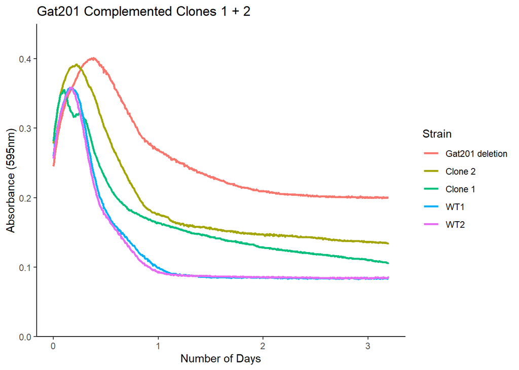

```r
PRPlot <- ggplot(data=normalisedOD %>%
                dplyr::filter(Strain != ""),
                aes(x=Time, y=OD_corrected, colour = Strain)) +
                stat_summary(fun = "median", geom = "line", size = 1) +
                scale_y_continuous(limits=c(0,0.45),expand=c(0,0)) +
        labs(x = "Number of Days",
             y = "Absorbance (595nm)",
             title = "Gat201 Complemented Clones 1 + 2") +
        theme_classic()

PRPlot
```

# Panel C

## Flow_cytometry_analysis_LT_160222

### Define functions to load flow cytometry data, using FlowCore package

```r
repair_flow_colnames <- function(string) {
  string %>%
    stringr::str_replace_all(" ", "") %>%
    stringr::str_replace_all("PE-", "PE") %>%
    stringr::str_replace_all("-", "_")
}

read_fcs_tibble <- function(file,...) {
  read.FCS(file,...) %>%
    .@exprs %>%
    as_tibble %>%
    set_names(repair_flow_colnames(names(.)))
}
```

## Load samplesheet

```r
datadir <- "../Input/Flow_cytometry_data/"
#Will need to make a new sample sheet for each new set of strains/bioreps I do
straindir <- "../Input/Flow_cytometry_data/"
# Strain_Order <-  c("KN99ON", "CnLT0004.1ON", "CnLT0004.2ON", "CnLT0004.3ON", "CnLT0007.1ON", "CnLT0007.2ON", "CnLT0007.3ON")

samplesheet <- paste(straindir, "StrainsForFlowCytometry_170222.xlsx", sep = "/") %>%
  readxl::read_excel() %>%
  select(Strain, SampleLabel, Replicate, Filename) %>%
  mutate(SampleLabel = factor(SampleLabel))

samplesheet
```

```
## # A tibble: 28 x 4
##    Strain          SampleLabel  Replicate Filename
##    <chr>           <fct>        <chr>     <chr>
##  1 WT              KN99a        a         Specimen_001_wt_a.fcs
##  2 WTB             KN99b        b         Specimen_001_wt_b.fcs
##  3 WTC             KN99c        c         Specimen_001_wt_c.fcs
##  4 WTON            KN99ON       ON        Specimen_o,2f,n_wt_a.fcs
##  5 BR1             CnLT0004.1a  a         Specimen_001_4_1_a.fcs
##  6 mCardinal_BR1B  CnLT0004.1b  b         Specimen_001_4_1_b.fcs
##  7 mCardinal_BR1C  CnLT0004.1c  c         Specimen_001_4_1_c.fcs
##  8 mCardinal_BR1ON CnLT0004.1ON ON        Specimen_o,2f,n_4_1_a.fcs
##  9 BR2             CnLT0004.2a  a         Specimen_001_4_2_a.fcs
## 10 mCardinal_BR2B  CnLT0004.2b  b         Specimen_001_4_2_b.fcs
## # ... with 18 more rows
```

## Load Data

```r
#Check the specific gates for the datasets, this is a rough estimate of where the gates lie
flow_data_all <- samplesheet %>%
  group_by(Strain, SampleLabel, Replicate, Filename) %>%
  do( read_fcs_tibble(paste(datadir, .$Filename[1], sep = "/")) )

flow_data_gated_singlets <- flow_data_all %>%
  dplyr::filter(FSC_W > 50000, FSC_W < 90000,
                FSC_A > 80000, FSC_A < 220000)

flow_data_gated_budding <- flow_data_all %>%
  dplyr::filter(FSC_W > 90000, FSC_W < 150000,
                FSC_A > 60000, FSC_A < 250000)
```

## Inspect Flow Data

```r
flow_data_all
```

```
## # A tibble: 2,409,092 x 45
## # Groups:   Strain, SampleLabel, Replicate, Filename [28]
##    Strain SampleLabel Replicate Filename  FSC_A FSC_H  FSC_W  SSC_A SSC_H  SSC_W
##    <chr>  <fct>       <chr>     <chr>     <dbl> <dbl>  <dbl>  <dbl> <dbl>  <dbl>
##  1 71A    CnLT0007.1a a         Specime~ 92480. 66012 91813. 52016. 36433 93566.
##  2 71A    CnLT0007.1a a         Specime~ 87542. 77731 73808. 36058. 35910 65806.
##  3 71A    CnLT0007.1a a         Specime~ 71209. 65835 70885. 36120. 36492 64868.
##  4 71A    CnLT0007.1a a         Specime~ 74763  67247 72861. 38708. 37102 68373.
##  5 71A    CnLT0007.1a a         Specime~ 54894. 51237 70213. 20246. 20642 64279.
##  6 71A    CnLT0007.1a a         Specime~ 57674. 54400 69480. 17904. 18437 63643.
##  7 71A    CnLT0007.1a a         Specime~ 76235. 69042 72364. 29847. 30423 64295.
##  8 71A    CnLT0007.1a a         Specime~ 43348. 41139 69055. 19558. 20850 61474.
##  9 71A    CnLT0007.1a a         Specime~ 86578. 69213 81978. 33527. 28810 76267.
## 10 71A    CnLT0007.1a a         Specime~ 83557. 67351 81305. 51492. 44214 76324.
## # ... with 2,409,082 more rows, and 35 more variables: AlexaFluor647_A <dbl>,
## #   AlexaFluor647_H <dbl>, AlexaFluor700_A <dbl>, AlexaFluor700_H <dbl>,
## #   APC_Cy7_A <dbl>, APC_Cy7_H <dbl>, PEA <dbl>, PEH <dbl>, PETexasRed_A <dbl>,
## #   PETexasRed_H <dbl>, PETexasRed_W <dbl>, PECy5_A <dbl>, PECy5_H <dbl>,
## #   PECy5_W <dbl>, PECy5_5_A <dbl>, PECy5_5_H <dbl>, PECy7_A <dbl>,
## #   PECy7_H <dbl>, AlexaFluor488_A <dbl>, AlexaFluor488_H <dbl>, PerCP_A <dbl>,
## #   PerCP_H <dbl>, AlexaFluor405_A <dbl>, AlexaFluor405_H <dbl>, ...
```

```r
left_join(flow_data_all %>%
            group_by(Strain) %>%
            tally(),
          flow_data_gated_singlets %>%
            group_by(Strain) %>%
            tally(),
          by = "Strain",
          suffix = c("_all", "_gated_singlets") )
```

```
## # A tibble: 28 x 3
##    Strain  n_all n_gated_singlets
##    <chr>   <int>            <int>
##  1 71A     31766             7377
##  2 71B     28052             6045
##  3 71C     30385             7052
##  4 71ON   292005            92852
##  5 72A     29741             5781
##  6 72B     28295             5783
##  7 72C     29337             5696
##  8 72ON   294525           122158
##  9 73A     34875            16416
## 10 73B     37485            16593
## # ... with 18 more rows
```

## Plot

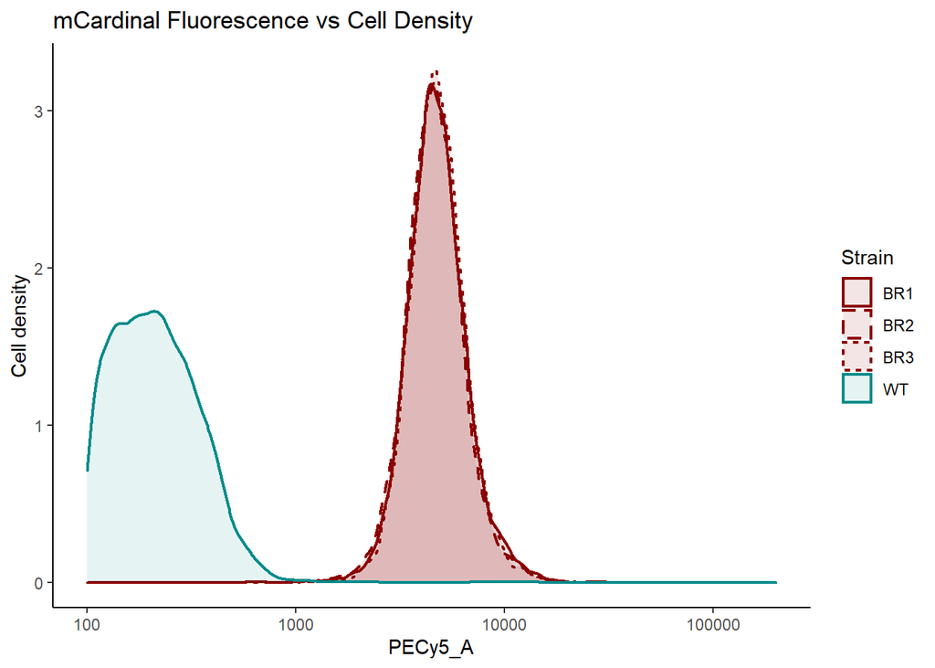

```r
options(scipen = 5)

Strains_ON <- c("KN99ON", "CnLT0004.1ON", "CnLT0004.2ON", "CnLT0004.3ON", "CnLT0007.1ON", "CnLT0007.2ON", "CnLT0007.3ON")
Strains_A <- c("WT", "BR1", "BR2", "BR3")
Strains_B <- c("KN99b", "CnLT0004.1b", "CnLT0004.2b", "CnLT0004.3b", "CnLT0007.1b", "CnLT0007.2b", "CnLT0007.3b")
Strains_C <- c("KN99c", "CnLT0004.1c", "CnLT0004.2c", "CnLT0004.3c", "CnLT0007.1c", "CnLT0007.2c", "CnLT0007.3c")
# flow_data_gated_singlets <- mutate(flow_data_gated_singlets, SampleLabel = factor(SampleLabel, Strain_Order))


mCardinal_Plot <- ggplot(data = dplyr::filter(flow_data_gated_singlets, Strain %in% Strains_A), aes(x = PECy5_A)) +
  geom_density(aes(colour = Strain, lty = Strain, fill = Strain), lwd = 0.8, alpha = 0.1) +
  scale_fill_manual(values = c("darkred", "darkred", "darkred","cyan4")) +
  scale_color_manual(values = c("darkred", "darkred", "darkred","cyan4")) +
  scale_linetype_manual(values = c("solid", "dashed", "dotted", "solid")) +
  scale_x_log10(limits = c(100, 200000)) +
  labs(title = 'mCardinal Fluorescence vs Cell Density', x = "PECy5_A", y = "Cell density") +
  theme_classic()

 mCardinal_Plot
```

# Draft Multipanel Figure

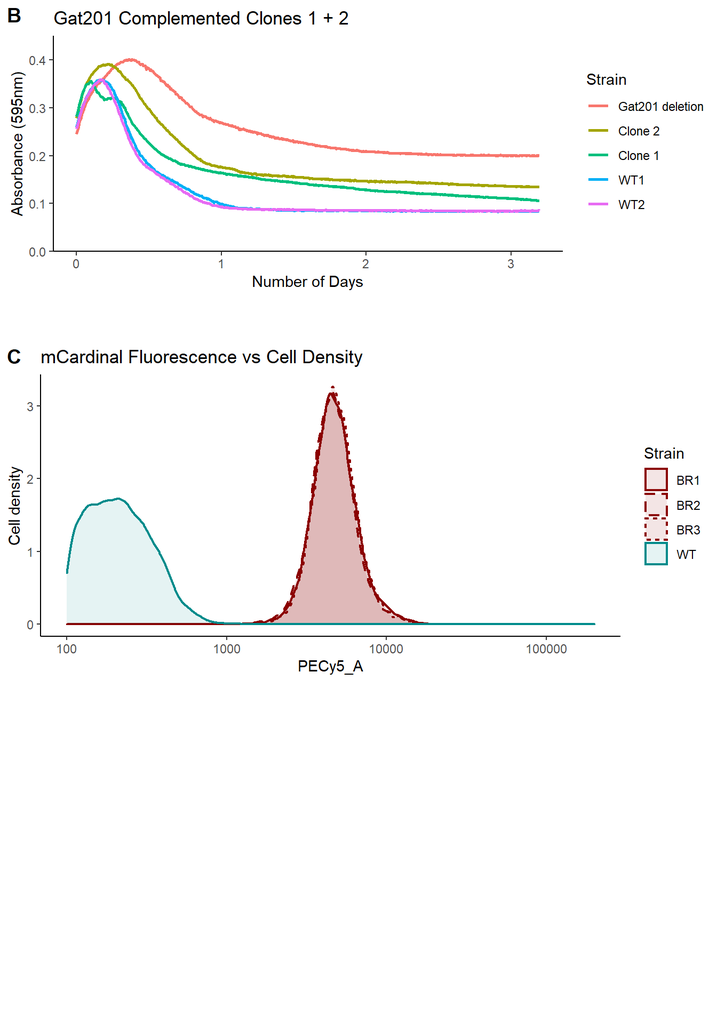

```r
figure_B2  <-
    plot_grid(
    PRPlot +
      theme(plot.margin = unit(c(0.1,0,0.5,0.1),"in")),
    mCardinal_Plot,
    theme(plot.margin = unit(c(1,0,0,1),"in")),
       ncol = 1,
    rel_heights = c(1,1),
    labels = c("B","C")
  )
plot_grid(
  figure_B2 ,
  ncol = 1,
  rel_widths = c(2))
```

# Save Multipanel Figure .jpeg, .svg and .Pdf

```r
ggsave("../Output/figure_B2 .jpeg",
figure_B2  ,width = 7,height=10)
```

```r
ggsave("../Output/figure_B2 .svg",
figure_B2  ,width = 7,height=10)
```

```r
ggsave("../Output/figure_B2 .pdf",
figure_B2  ,width = 7,height=10)
```